# Disaster Relief Project Part II

Chelsea Alvarado

4/28/2021

**SYS 6018 | Spring 2021 | University of Virginia**

# Introduction

This project is aimed at being able to identify the location of displaced Haitian’s after the catastrophic 2010 earthquake using a characteristic blue tarp. The motivation behind this project is to be able to quickly identify locations so that rescue workers can provide needed assistance such as food and medicine. The data set being used consists of three predictor variables/features that represent RGB values and a response variable which is a Class representing what each observation represents based on the combination of RGB values. In its original form the data is multiclass. This project will train data on seven different models including Logistic Regression, Linear Discriminant Analysis, Quadratic Discriminant Analysis, K-Nearest Neighbors, Penalized Logistic Regression, Random Forest, and Support Vector Machines. The Penalized Logistic Regression Model will be chosen by comparing Ridge, Lasso, and Elastic Net Regression and picking the model with the best accuracy as the final penalized logistic regression model. The same approach will be used to identify the best SVM model by comparing the accuracy of a linear, radial and polynomial kernel. The training data will consist of the data file ‘Haiti_Pixels.csv’ and our test/hold_out data set will come from the provided zip file. The holdout data will be wrangled and put together to use for predictions. All of our values will be scaled to have a mean of zero and standard deviation of 1. The models will train on a training set while also using 10-fold Cross-Validation and then test on test data for accuracy and predictive ability. Due to the multiclass nature of the data, our response variable will be manipulated to be either “Blue Tarp” or " Not Tarp“.”. Tuning parameters(k, lambda, gamma, cost, etc) will be selected using cross validation. The results of each model will be presented at the end of the report in a table along with conclusions. This project relies heavily on the use of the caret library for finding the ‘best’ model for each different alogrithm.

# Data Manipulation/Wrangling

## Hold Out Data

```r
#read in hold out data, define directory path
directory <- "C:/Users/17039/Documents/MSDS/Spring 2021/SYS6018/Project" # where I want data to go

filesin<-unzip(file.path(directory, "Hold+Out+Data.zip"), list=TRUE) #list out files in zip
#unzip folder and put files in directory
unzip(file.path(directory, "Hold+Out+Data.zip"), exdir = directory)
```

### Conversion of TXT Files into Dataframes

```
#>  [1] "; ENVI Output of ROIs (5.5.1) [Tue Nov 05 11:28:14 2019]"
#>  [2] "; Number of ROIs: 1"
#>  [3] "; File Dimension: 4001 x 5447"
#>  [4] ";"
#>  [5] "; ROI name: Region #1"
#>  [6] "; ROI rgb value: {255, 0, 0}"
#>  [7] "; ROI npts: 3991823"
#>  [8] ";       ID     X     Y      Map X       Map Y        Lat         Lon   B1   B2   B3"
#>  [9] "         1  1745  1128  769849.55  2049926.90  18.522675  -72.443989  104   89   63"
#> [10] "         2  1745  1129  769849.55  2049926.82  18.522674  -72.443989  101   80   60"
#> [11] "         3  1746  1129  769849.64  2049926.82  18.522674  -72.443989  103   87   69"
#> [12] "         4  1747  1129  769849.72  2049926.82  18.522674  -72.443988  107   93   72"
#> [13] "         5  1748  1129  769849.80  2049926.82  18.522674  -72.443987  109   99   68"
#> [14] "         6  1744  1129  769849.47  2049926.82  18.522674  -72.443990  103   73   53"
#> [15] "         7  1743  1130  769849.39  2049926.74  18.522674  -72.443991  100   79   56"
```

```
#>  [1] "; ENVI Output of ROIs (5.5.1) [Tue Nov 05 11:47:24 2019]"
#>  [2] "; Number of ROIs: 1"
#>  [3] "; File Dimension: 4178 x 6402"
#>  [4] ";"
#>  [5] "; ROI name: Blue Tarps"
#>  [6] "; ROI rgb value: {255, 0, 0}"
#>  [7] "; ROI npts: 4446"
#>  [8] ";    ID     X     Y      Map X       Map Y        Lat         Lon   B1   B2   B3"
#>  [9] "      1   443   147  772350.00  2049951.37  18.522574  -72.420319   77   94   99"
#> [10] "      2   441   148  772349.84  2049951.29  18.522574  -72.420321   79   98  103"
#> [11] "      3   442   148  772349.92  2049951.29  18.522574  -72.420320   77   99  102"
#> [12] "      4   443   148  772350.00  2049951.29  18.522574  -72.420319   76   94   99"
#> [13] "      5   440   148  772349.76  2049951.29  18.522574  -72.420322   80   95  103"
#> [14] "      6   438   149  772349.60  2049951.21  18.522573  -72.420323   80   96  107"
#> [15] "      7   439   149  772349.68  2049951.21  18.522573  -72.420322   80   96  106"
```

```
#>  [1] "; ENVI Output of ROIs (5.5.1) [Tue Nov 05 11:48:38 2019]"
#>  [2] "; Number of ROIs: 1"
#>  [3] "; File Dimension: 4178 x 6402"
#>  [4] ";"
#>  [5] "; ROI name: Region #1"
#>  [6] "; ROI rgb value: {0, 255, 0}"
#>  [7] "; ROI npts: 305211"
#>  [8] ";      ID     X     Y      Map X       Map Y        Lat         Lon   B1   B2   B3"
#>  [9] "        1  2920  2146  772548.95  2049790.81  18.521099  -72.418458   68   62   58"
#> [10] "        2  2921  2146  772549.03  2049790.81  18.521099  -72.418457   65   62   57"
#> [11] "        3  2922  2146  772549.11  2049790.81  18.521099  -72.418457   65   62   57"
#> [12] "        4  2923  2146  772549.19  2049790.81  18.521099  -72.418456   64   63   57"
#> [13] "        5  2919  2146  772548.87  2049790.81  18.521099  -72.418459   72   64   59"
#> [14] "        6  2919  2147  772548.87  2049790.73  18.521098  -72.418459   72   66   59"
#> [15] "        7  2920  2147  772548.95  2049790.73  18.521098  -72.418458   69   63   58"
```

```
#>  [1] "; ENVI Output of ROIs (5.5.1) [Tue Nov 05 11:55:39 2019]"
#>  [2] "; Number of ROIs: 1"
#>  [3] "; File Dimension: 4583 x 6796"
#>  [4] ";"
#>  [5] "; ROI name: Blue Tarps"
#>  [6] "; ROI rgb value: {0, 0, 255}"
#>  [7] "; ROI npts: 6828"
#>  [8] ";    ID     X     Y      Map X       Map Y        Lat         Lon   B1   B2   B3"
#>  [9] "      1  1785   570  772940.91  2049991.90  18.522864  -72.414721   88  102  123"
#> [10] "      2  1784   571  772940.83  2049991.82  18.522863  -72.414722   88  103  126"
#> [11] "      3  1785   571  772940.91  2049991.82  18.522863  -72.414721   88  103  126"
#> [12] "      4  1786   571  772940.99  2049991.82  18.522863  -72.414720   89  103  125"
#> [13] "      5  1787   572  772941.07  2049991.74  18.522862  -72.414719   90  104  126"
#> [14] "      6  1783   572  772940.75  2049991.74  18.522862  -72.414723   88  104  127"
#> [15] "      7  1784   572  772940.83  2049991.74  18.522862  -72.414722   88  104  127"
```

```
#>  [1] "; ENVI Output of ROIs (5.5.1) [Tue Nov 05 11:56:48 2019]"
#>  [2] "; Number of ROIs: 1"
#>  [3] "; File Dimension: 4583 x 6796"
#>  [4] ";"
#>  [5] "; ROI name: Region #1"
#>  [6] "; ROI rgb value: {255, 0, 0}"
#>  [7] "; ROI npts: 295510"
#>  [8] ";      ID     X     Y      Map X       Map Y        Lat         Lon   B1   B2   B3"
#>  [9] "        1  2296   222  772981.96  2050019.86  18.523111  -72.414329  116  138  120"
#> [10] "        2  2296   223  772981.96  2050019.78  18.523110  -72.414329  104  121  109"
#> [11] "        3  2295   223  772981.88  2050019.78  18.523110  -72.414330  106  125  109"
#> [12] "        4  2290   224  772981.47  2050019.70  18.523110  -72.414333  114  135  109"
#> [13] "        5  2291   224  772981.55  2050019.70  18.523110  -72.414333  111  133  107"
#> [14] "        6  2292   224  772981.63  2050019.70  18.523110  -72.414332  107  122  103"
#> [15] "        7  2293   224  772981.72  2050019.70  18.523110  -72.414331  105  117  101"
```

```
#>  [1] "; ENVI Output of ROIs (5.5.1) [Tue Nov 05 12:12:47 2019]"
#>  [2] "; Number of ROIs: 1"
#>  [3] "; File Dimension: 4753 x 6746"
#>  [4] ";"
#>  [5] "; ROI name: Region #1"
#>  [6] "; ROI rgb value: {255, 0, 0}"
#>  [7] "; ROI npts: 3206"
#>  [8] ";    ID     X     Y      Map X       Map Y        Lat         Lon   B1   B2   B3"
#>  [9] "      1  1758   657  775216.66  2049967.14  18.522344  -72.393185   91  100  132"
#> [10] "      2  1757   657  775216.58  2049967.14  18.522344  -72.393186   88  108  140"
#> [11] "      3  1758   658  775216.66  2049967.06  18.522344  -72.393185   85  100  130"
#> [12] "      4  1759   658  775216.74  2049967.06  18.522344  -72.393184   88  101  135"
#> [13] "      5  1760   658  775216.82  2049967.06  18.522344  -72.393184   91  104  141"
#> [14] "      6  1761   658  775216.90  2049967.06  18.522344  -72.393183   94  113  147"
#> [15] "      7  1762   658  775216.98  2049967.06  18.522344  -72.393182   97  114  150"
```

```
#>  [1] "; ENVI Output of ROIs (5.5.1) [Tue Nov 05 12:14:00 2019]"
#>  [2] "; Number of ROIs: 1"
#>  [3] "; File Dimension: 4753 x 6746"
#>  [4] ";"
#>  [5] "; ROI name: Region #2"
#>  [6] "; ROI rgb value: {0, 255, 0}"
#>  [7] "; ROI npts: 409698"
#>  [8] ";      ID     X     Y      Map X       Map Y        Lat         Lon   B1   B2   B3"
#>  [9] "        1  2157  1125  775248.71  2049929.55  18.522001  -72.392887   83   75   65"
#> [10] "        2  2156  1125  775248.63  2049929.55  18.522001  -72.392888   81   75   65"
#> [11] "        3  2152  1126  775248.31  2049929.47  18.522000  -72.392891   84   78   66"
#> [12] "        4  2153  1126  775248.39  2049929.47  18.522000  -72.392890   81   78   65"
#> [13] "        5  2154  1126  775248.47  2049929.47  18.522000  -72.392889   80   79   65"
#> [14] "        6  2155  1126  775248.55  2049929.47  18.522000  -72.392888   79   76   64"
#> [15] "        7  2156  1126  775248.63  2049929.47  18.522000  -72.392888   78   74   64"
```

### Conversion into one single Dataframe for all 2 million+ observations

```r
#create one central df
hold_out <- data.frame()

#merge first df into central df
hold_out<-rbind(hold_out, ortho057_noblue)

#repeat for remaining dfs
hold_out<-rbind(hold_out, ortho067_blue)
hold_out<-rbind(hold_out, ortho067_blue2)
hold_out<-rbind(hold_out, ortho067_noblue)
hold_out<-rbind(hold_out, ortho069_blue)
hold_out<-rbind(hold_out, ortho069_noblue)
hold_out<-rbind(hold_out, ortho078_blue)
hold_out<-rbind(hold_out, ortho078_noblue)

#change class labels
hold_out$Class[hold_out$Class =="Non-blue Tarp"]<-"Not.Tarp"
hold_out$Class[hold_out$Class =="Blue Tarp"]<-"Blue.Tarp"

#make sure Class is a factor
hold_out$Class <- as.factor(hold_out$Class)

#change reference class
hold_out$Class <-relevel(hold_out$Class, ref = "Not.Tarp")

#scramble data
set.seed(4444)
hold_out<-hold_out[sample(1:nrow(hold_out)),]

#get rid of any missing values
dim(hold_out)
```

```
#> [1] 2008623       4
```

```r
hold_out <- na.omit(hold_out)
dim(hold_out) # no missing values
```

```
#> [1] 2008623       4
```

```r
#check number of obs for each class
blue <- sum(hold_out$Class == 'Blue.Tarp')
not <- sum(hold_out$Class == 'Not.Tarp')
blue
```

```
#> [1] 18926
```

```r
not
```

```
#> [1] 1989697
```

## Haiti Pixels Data

### EDA/ Visualization

```r
#load in Haiti Pixel Data
setwd("~/MSDS/Spring 2021/SYS6018/Project")
pix_data <- read.csv("HaitiPixels.csv")
pix_data <- as.data.frame(pix_data)
#attach(pix_data)

#EDA
#quantitative
names(pix_data)
```

```
#> [1] "Class" "Red"   "Green" "Blue"
```

```r
head(pix_data)
```

```
#>        Class Red Green Blue
#> 1 Vegetation  64    67   50
#> 2 Vegetation  64    67   50
#> 3 Vegetation  64    66   49
#> 4 Vegetation  75    82   53
#> 5 Vegetation  74    82   54
#> 6 Vegetation  72    76   52
```

```r
summary(pix_data)
```

```
#>     Class                Red          Green            Blue
#>  Length:63241       Min.   : 48   Min.   : 48.0   Min.   : 44.0
#>  Class :character   1st Qu.: 80   1st Qu.: 78.0   1st Qu.: 63.0
#>  Mode  :character   Median :163   Median :148.0   Median :123.0
#>                     Mean   :163   Mean   :153.7   Mean   :125.1
#>                     3rd Qu.:255   3rd Qu.:226.0   3rd Qu.:181.0
#>                     Max.   :255   Max.   :255.0   Max.   :255.0
```

```r
dim(pix_data)
```

```
#> [1] 63241     4
```

```r
#check how many of each classification we have
sum(pix_data$Class== "Vegetation")
```

```
#> [1] 26006
```

```r
sum(pix_dataClass== "Blue Tarp")
```

[output not shown]

```r
sum(pix_dataClass=="Rooftop")
```

[output not shown]

```r
sum(pix_dataClass=="Soil")
```

[output not shown]

```r
sum(pix_dataClass=="Various Non-Tarp")
```

[output not shown]

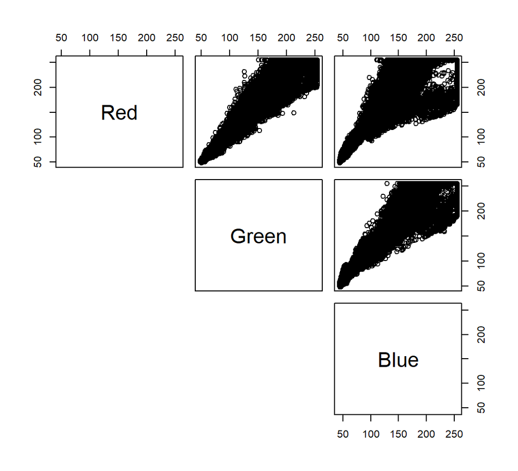

```r
#graphical
pairs(pix_data[,2:4], lower.panel = NULL)
```

```r
cor(pix_data[,2:4])
```

```
#>             Red     Green      Blue
#> Red   1.0000000 0.9815987 0.9355294
#> Green 0.9815987 1.0000000 0.9648024
#> Blue  0.9355294 0.9648024 1.0000000
```

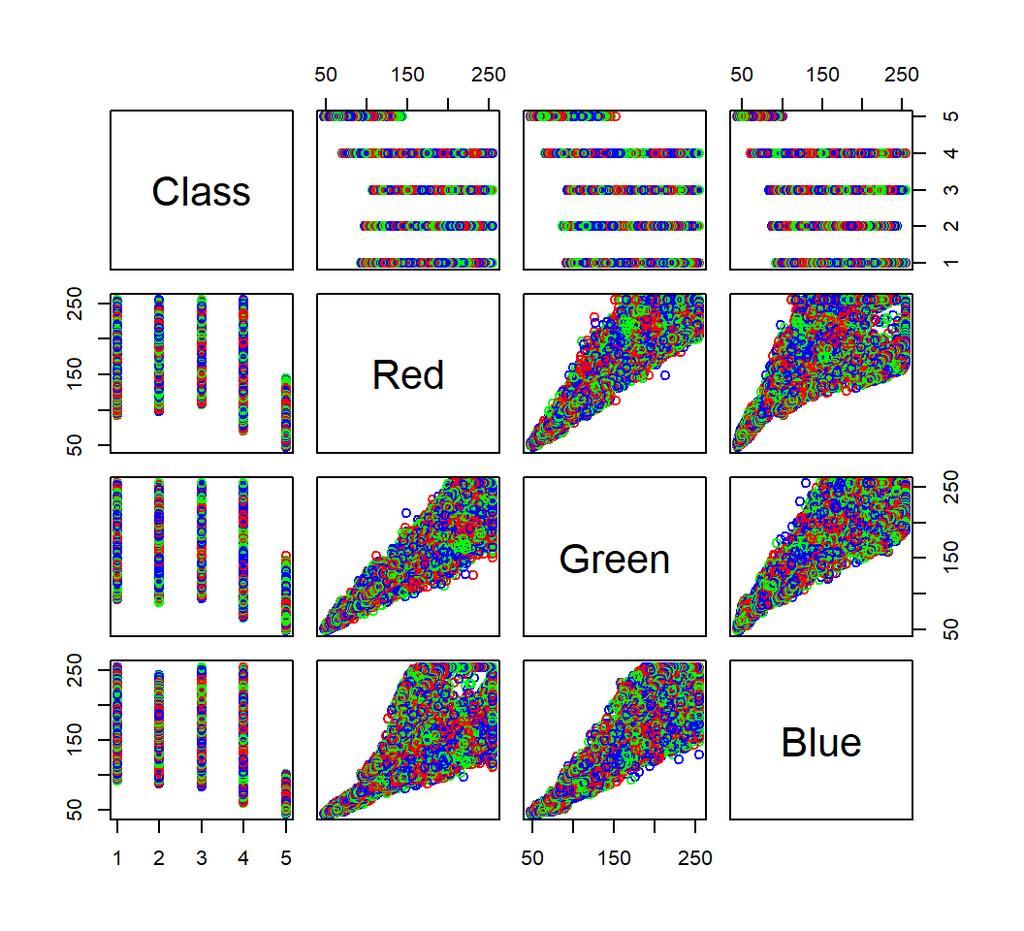

```r
plot(pix_data, col= c("red","green","blue"))
```

### Data preparation(training data)

```r
#turn all class labels into binary choice
pix_data$Class[pix_data$Class=="Blue Tarp"] <- "Blue.Tarp"
pix_data$Class[pix_data$Class=="Various Non-Tarp"] <- "Not.Tarp"
pix_data$Class[pix_data$Class=="Soil"] <- "Not.Tarp"
pix_data$Class[pix_data$Class=="Vegetation"] <- "Not.Tarp"
pix_data$Class[pix_data$Class=="Rooftop"] <- "Not.Tarp"

#scramble data
set.seed(4444)
pix_data<-pix_data[sample(1:nrow(pix_data)),]

#factor class
pix_data$Class <- as.factor(pix_data$Class)

#class counts
blue.p <- sum(pix_data$Class == "Blue.Tarp")
not.p <- sum(pix_data$Class == "Not.Tarp")

blue.p
```

```
#> [1] 2022
```

```r
not.p
```

```
#> [1] 61219
```

```r
#scale
pix_datan <- preProcess(pix_data)
pix_data <- predict(pix_datan, pix_data)
hold_out<- predict(pix_datan, hold_out)
```

# Model Training

## Logistic Regression

### Model Run

```r
#prep data for log reg
log_df<-pix_data
#check levels and relevel
levels(log_df$Class)
```

```
#> [1] "Blue.Tarp" "Not.Tarp"
```

```r
log_df$Class <-relevel(log_df$Class, ref = "Not.Tarp")

#run log reg
set.seed(4658)
specs <- trainControl(method = "cv", number = 10, classProbs=TRUE)

set.seed(356)

#model
log.mod <- train(log_df[,2:4],log_df[,1], method = "glm", family = "binomial", trControl = specs)

#model summary
log.mod
```

```
#> Generalized Linear Model
#>
#> 63241 samples
#>     3 predictor
#>     2 classes: 'Not.Tarp', 'Blue.Tarp'
#>
#> No pre-processing
#> Resampling: Cross-Validated (10 fold)
#> Summary of sample sizes: 56917, 56918, 56916, 56917, 56917, 56917, ...
#> Resampling results:
#>
#>   Accuracy   Kappa
#>   0.9952879  0.9207191
```

```r
summary(log.mod)
```

```
#>
#> Call:
#> NULL
#>
#> Deviance Residuals:
#>     Min       1Q   Median       3Q      Max
#> -3.4266  -0.0205  -0.0015   0.0000   3.7911
#>
#> Coefficients:
#>             Estimate Std. Error z value Pr(>|z|)
#> (Intercept) -16.6449     0.4907  -33.92   <2e-16 ***
#> Red         -20.5325     0.9952  -20.63   <2e-16 ***
#> Green       -15.8585     0.9660  -16.42   <2e-16 ***
#> Blue         29.0026     0.9506   30.51   <2e-16 ***
#> ---
#> Signif. codes:  0 '***' 0.001 '**' 0.01 '*' 0.05 '.' 0.1 ' ' 1
#>
#> (Dispersion parameter for binomial family taken to be 1)
#>
#>     Null deviance: 17901.6  on 63240  degrees of freedom
#> Residual deviance:  1769.5  on 63237  degrees of freedom
#> AIC: 1777.5
#>
#> Number of Fisher Scoring iterations: 12
```

### Prediction,Confusion Matrix, and ROC/AUC Curve

```r
#predicting against test data
pred<-predict(log.mod,hold_out)

#confusion matrix
c.matrix <- confusionMatrix(data=pred, hold_out$Class)
c.matrix
```

```
#> Confusion Matrix and Statistics
#>
#>            Reference
#> Prediction  Not.Tarp Blue.Tarp
#>   Not.Tarp   1969385       170
#>   Blue.Tarp    20312     18756
#>
#>                Accuracy : 0.9898
#>                  95% CI : (0.9897, 0.9899)
#>     No Information Rate : 0.9906
#>     P-Value [Acc > NIR] : 1
#>
#>                   Kappa : 0.6423
#>
#>  Mcnemar's Test P-Value : <2e-16
#>
#>             Sensitivity : 0.9898
#>             Specificity : 0.9910
#>          Pos Pred Value : 0.9999
#>          Neg Pred Value : 0.4801
#>              Prevalence : 0.9906
#>          Detection Rate : 0.9805
#>    Detection Prevalence : 0.9805
#>       Balanced Accuracy : 0.9904
#>
#>        'Positive' Class : Not.Tarp
#>
```

```r
#ROC/AUC
library(pROC)
library(randomForest)

log.pred <- predict(log.mod, newdata=hold_out, probability = TRUE)
log.pred <- as.ordered(log.pred)

log.roc <- roc(hold_out$Class, log.pred)
```

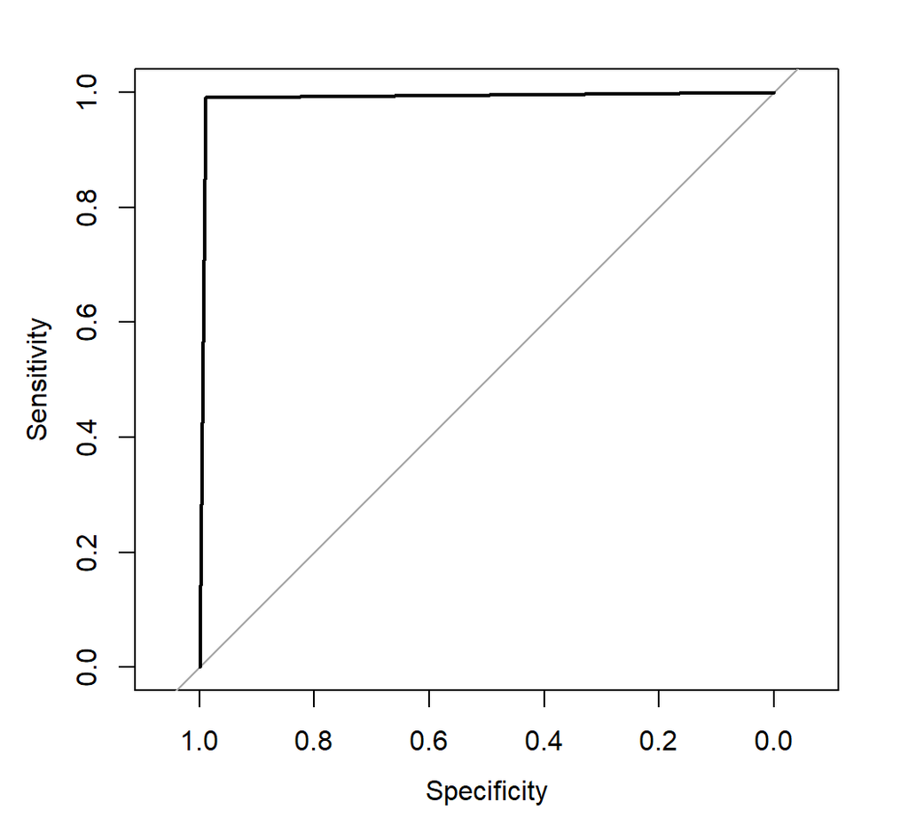

```r
plot(log.roc,ylim=c(0,1))
```

```r
auc.log <-log.roc$auc
```

### Manual Threshold testing

```r
#code I ran to test thresholds
#regression
pix_log<-glm(Class~Red+Green+Blue,data=log_df, family=binomial)
summary(pix_log)
```

```
#>
#> Call:
#> glm(formula = Class ~ Red + Green + Blue, family = binomial,
#>     data = log_df)
#>
#> Deviance Residuals:
#>     Min       1Q   Median       3Q      Max
#> -3.4266  -0.0205  -0.0015   0.0000   3.7911
#>
#> Coefficients:
#>             Estimate Std. Error z value Pr(>|z|)
#> (Intercept) -16.6449     0.4907  -33.92   <2e-16 ***
#> Red         -20.5325     0.9952  -20.63   <2e-16 ***
#> Green       -15.8585     0.9660  -16.42   <2e-16 ***
#> Blue         29.0026     0.9506   30.51   <2e-16 ***
#> ---
#> Signif. codes:  0 '***' 0.001 '**' 0.01 '*' 0.05 '.' 0.1 ' ' 1
#>
#> (Dispersion parameter for binomial family taken to be 1)
#>
#>     Null deviance: 17901.6  on 63240  degrees of freedom
#> Residual deviance:  1769.5  on 63237  degrees of freedom
#> AIC: 1777.5
#>
#> Number of Fisher Scoring iterations: 12
```

```r
#preparing data for confusion matrix
pix_log_prob<- predict(pix_log, hold_out, type="response")
pix_log_pred<-rep("Non.Tarp",length(pix_log_prob))  #non tarp classes lumped together all non blue tarp values under the label "Non.Tarp"
pix_log_pred[pix_log_prob>.5]="Blue.Tarp"

#confusion matrix
table(pix_log_pred,hold_out$Class)
```

```
#>
#> pix_log_pred Not.Tarp Blue.Tarp
#>    Blue.Tarp    20312     18756
#>    Non.Tarp   1969385       170
```

```r
#correct predictions
correct.log <- mean(pix_log_pred==hold_out$Class)
correct.log
```

```
#> [1] 0.00933774
```

```r
#test error rate
error_log_5<- mean(pix_log_pred!=hold_out$Class)
error_log_5
```

```
#> [1] 0.9906623
```

```r
##using a higher threshold value
#preparing data for confusion matrix
pix_log_prob<- predict(pix_log, hold_out, type="response")
pix_log_pred<-rep("Non.Tarp",length(pix_log_prob)) #since log reg produces binary response values I lumped together all non blue tarp values under the label "Not Tarp"
pix_log_pred[pix_log_prob>.75]="Blue.Tarp"

#confusion matrix
table(pix_log_pred,hold_out$Class)
```

```
#>
#> pix_log_pred Not.Tarp Blue.Tarp
#>    Blue.Tarp     8815     18648
#>    Non.Tarp   1980882       278
```

```r
#correct predictions
mean(pix_log_pred==hold_out$Class)
```

```
#> [1] 0.009283972
```

```r
#test error rate
error_log_7<- mean(pix_log_pred!=hold_out$Class)
error_log_7
```

```
#> [1] 0.990716
```

```r
threshold.log <- 0.7
```

### CV Table Calculations

```r
#calculating values for CV table
tp.log <- c.matrix$table[1,1] #true positive
fp.log <-c.matrix$table[1,2]# false positive
fn.log <- c.matrix$table[2,1] #false negative
tn.log <-c.matrix$table[2,2] # true negative
cp.log<- tp.log + fn.log #condition positive (true positive + false negative)
cn.log <- fp.log + tn.log #condition negative (false positive + true negative)
total.log <- tp.log+fp.log+fn.log+tn.log

precision.log <- tp.log/(tp.log+fp.log)

tpr.log <- c.matrix$byClass['Sensitivity'] #true positive rate/sensitivity
fpr.log <- fp.log/cn.log #false positive rate
accuracy.log <- (tp.log+tn.log)/total.log
```

## Linear Discriminant Analysis (LDA)

```r
library(MASS)
#train model
lda.spec <- trainControl(method="cv", number = 10, savePredictions = TRUE)

lda.mod <- train(Class~., data = pix_data, method = "lda", trControl = lda.spec)
lda.mod
```

```
#> Linear Discriminant Analysis
#>
#> 63241 samples
#>     3 predictor
#>     2 classes: 'Blue.Tarp', 'Not.Tarp'
#>
#> No pre-processing
#> Resampling: Cross-Validated (10 fold)
#> Summary of sample sizes: 56916, 56917, 56918, 56917, 56916, 56917, ...
#> Resampling results:
#>
#>   Accuracy   Kappa
#>   0.9838553  0.7520211
```

```r
#preparing data for confusion matrix
lda.pred<-predict(lda.mod, newdata=hold_out)
```

### Prediction,Confusion Matrix, and ROC/AUC Curve

```r
#confusion matrix
c.matrixlda<- confusionMatrix(data=lda.pred, reference=hold_out$Class)
c.matrixlda
```

```
#> Confusion Matrix and Statistics
#>
#>            Reference
#> Prediction  Not.Tarp Blue.Tarp
#>   Not.Tarp   1955993      2546
#>   Blue.Tarp    33704     16380
#>
#>                Accuracy : 0.982
#>                  95% CI : (0.9818, 0.9821)
#>     No Information Rate : 0.9906
#>     P-Value [Acc > NIR] : 1
#>
#>                   Kappa : 0.4674
#>
#>  Mcnemar's Test P-Value : <2e-16
#>
#>             Sensitivity : 0.9831
#>             Specificity : 0.8655
#>          Pos Pred Value : 0.9987
#>          Neg Pred Value : 0.3271
#>              Prevalence : 0.9906
#>          Detection Rate : 0.9738
#>    Detection Prevalence : 0.9751
#>       Balanced Accuracy : 0.9243
#>
#>        'Positive' Class : Not.Tarp
#>
```

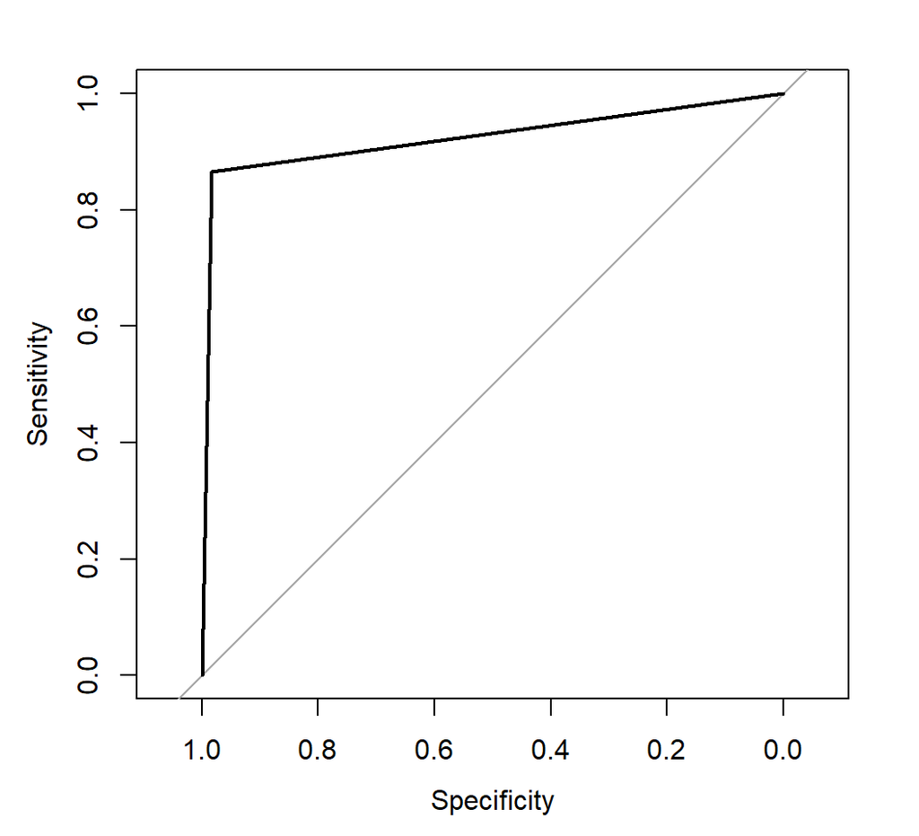

```r
#ROC/AUC
pred.lda <-predict(lda.mod, hold_out, probability = TRUE)
pred.lda<- as.ordered(pred.lda)

roc.lda <-multiclass.roc(predictor = pred.lda, response = hold_out$Class, plot=TRUE)
```

```r
auc.lda <- roc.lda$auc

#calculating values for CV table
tp.lda <- c.matrix$table[1,1]  #true positive
fp.lda <- c.matrix$table[1,2] # false positive
fn.lda <- c.matrix$table[2,1]  #false negative
tn.lda <- c.matrix$table[2,2]  # true negative
cp.lda<- tp.lda + fn.lda #condition positive (true positive + false negative)
cn.lda <- fp.lda + tn.lda #condition negative (false positive + true negative)
total.lda <- tp.lda+fp.lda+fn.lda+tn.lda

precision.lda <- tp.lda/(tp.lda+fp.lda)

tpr.lda <- (tp.lda/cp.lda) #true positive rate/sensitivity
fpr.lda <- (fp.lda/cn.lda) #false positive rate
accuracy.lda <- c.matrixlda$overall["Accuracy"]
```

## Quadratic Discriminant Analysis (QDA)

```r
qda.spec <- trainControl(method="cv", number = 10)

qda.mod <- train(Class~., data = pix_data, method = "qda", trControl = lda.spec)

qda.mod
```

```
#> Quadratic Discriminant Analysis
#>
#> 63241 samples
#>     3 predictor
#>     2 classes: 'Blue.Tarp', 'Not.Tarp'
#>
#> No pre-processing
#> Resampling: Cross-Validated (10 fold)
#> Summary of sample sizes: 56917, 56917, 56917, 56917, 56916, 56917, ...
#> Resampling results:
#>
#>   Accuracy   Kappa
#>   0.9945763  0.9052999
```

### Prediction,Confusion Matrix, and ROC/AUC Curve

```r
#predict on model
qda.pred<-predict(qda.mod, newdata=hold_out)

#confusion matrix
c.matrixqda<- confusionMatrix(data=qda.pred, reference=hold_out$Class)
c.matrixqda
```

```
#> Confusion Matrix and Statistics
#>
#>            Reference
#> Prediction  Not.Tarp Blue.Tarp
#>   Not.Tarp   1982817      8489
#>   Blue.Tarp     6880     10437
#>
#>                Accuracy : 0.9923
#>                  95% CI : (0.9922, 0.9925)
#>     No Information Rate : 0.9906
#>     P-Value [Acc > NIR] : < 2.2e-16
#>
#>                   Kappa : 0.5721
#>
#>  Mcnemar's Test P-Value : < 2.2e-16
#>
#>             Sensitivity : 0.9965
#>             Specificity : 0.5515
#>          Pos Pred Value : 0.9957
#>          Neg Pred Value : 0.6027
#>              Prevalence : 0.9906
#>          Detection Rate : 0.9872
#>    Detection Prevalence : 0.9914
#>       Balanced Accuracy : 0.7740
#>
#>        'Positive' Class : Not.Tarp
#>
```

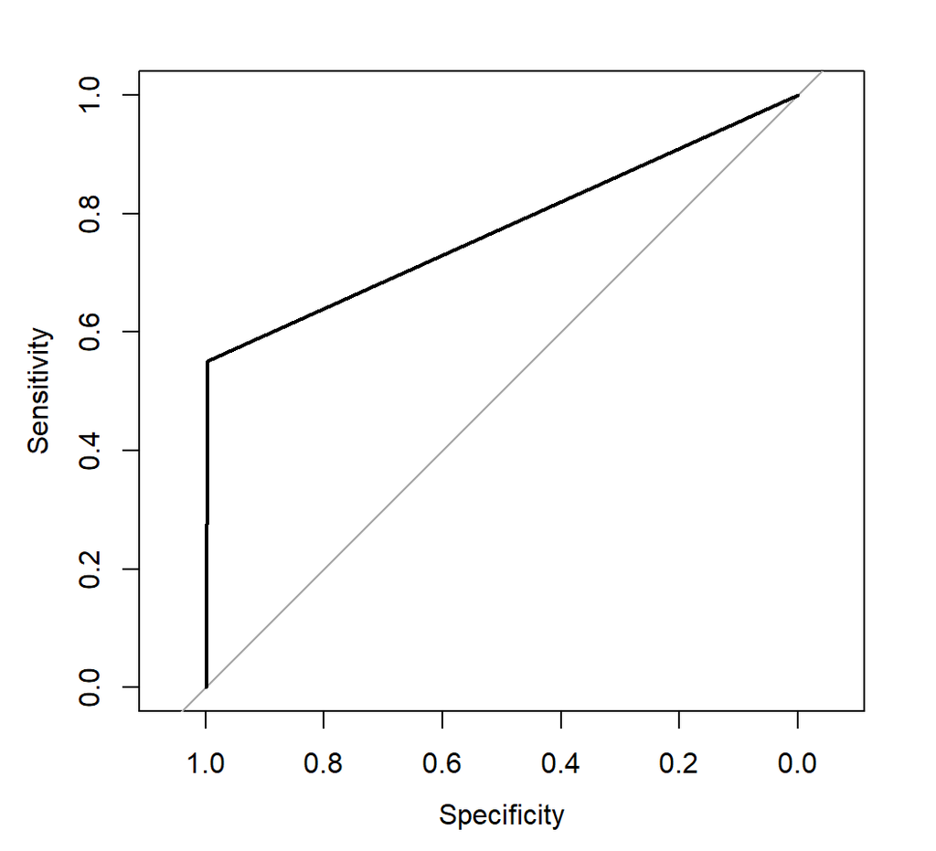

```r
#ROC/AUC
pred.qda <-predict(qda.mod, hold_out, probability = TRUE)
pred.qda <- as.ordered(pred.qda)

roc.qda <-multiclass.roc(predictor = pred.qda, response = hold_out$Class, plot=TRUE)
```

```r
auc.qda <- roc.qda$auc

#calculating values for CV table
#confusion matrix
tp.qda <- (c.matrixqda$table[1,1]) #true positive
fp.qda <-(c.matrixqda$table[1,2]) # false positive
fn.qda <- (c.matrixqda$table[2,1]) #false negative
tn.qda <-(c.matrixqda$table[2,2]) # true negative
cp.qda<- tp.qda + fn.qda #condition positive
cn.qda <- fp.qda + tn.qda #condition negative
total.qda <- tp.qda+fp.qda+fn.qda+tn.qda

precision.qda <- tp.qda/(tp.qda+fp.qda)

tpr.qda <- tp.qda/cp.qda #true positive rate/sensitivity
fpr.qda <- fp.qda/cn.qda #false positive rate
accuracy.qda <- c.matrixqda$overall["Accuracy"]
```

## K-Nearest Neighbors (KNN)

```r
library(class)
set.seed(145)
specs <- trainControl(method = "cv", number = 10)

#model
knn.mod <- train(pix_data[,2:4], pix_data[,1],method="knn", trControl=specs, metric = "Accuracy")
knn.mod
```

```
#> k-Nearest Neighbors
#>
#> 63241 samples
#>     3 predictor
#>     2 classes: 'Blue.Tarp', 'Not.Tarp'
#>
#> No pre-processing
#> Resampling: Cross-Validated (10 fold)
#> Summary of sample sizes: 56916, 56917, 56918, 56917, 56917, 56917, ...
#> Resampling results across tuning parameters:
#>
#>   k  Accuracy   Kappa
#>   5  0.9972328  0.9554664
#>   7  0.9972486  0.9558582
#>   9  0.9972328  0.9556270
#>
#> Accuracy was used to select the optimal model using the largest value.
#> The final value used for the model was k = 7.
```

```r
#prediction
knn.pred<-predict(knn.mod, hold_out)
#confusion matrix
c.matrixknn <- confusionMatrix(data=knn.pred, reference = hold_out$Class)
c.matrixknn
```

```
#> Confusion Matrix and Statistics
#>
#>            Reference
#> Prediction  Not.Tarp Blue.Tarp
#>   Not.Tarp   1977067      2714
#>   Blue.Tarp    12630     16212
#>
#>                Accuracy : 0.9924
#>                  95% CI : (0.9922, 0.9925)
#>     No Information Rate : 0.9906
#>     P-Value [Acc > NIR] : < 2.2e-16
#>
#>                   Kappa : 0.6751
#>
#>  Mcnemar's Test P-Value : < 2.2e-16
#>
#>             Sensitivity : 0.9937
#>             Specificity : 0.8566
#>          Pos Pred Value : 0.9986
#>          Neg Pred Value : 0.5621
#>              Prevalence : 0.9906
#>          Detection Rate : 0.9843
#>    Detection Prevalence : 0.9856
#>       Balanced Accuracy : 0.9251
#>
#>        'Positive' Class : Not.Tarp
#>
```

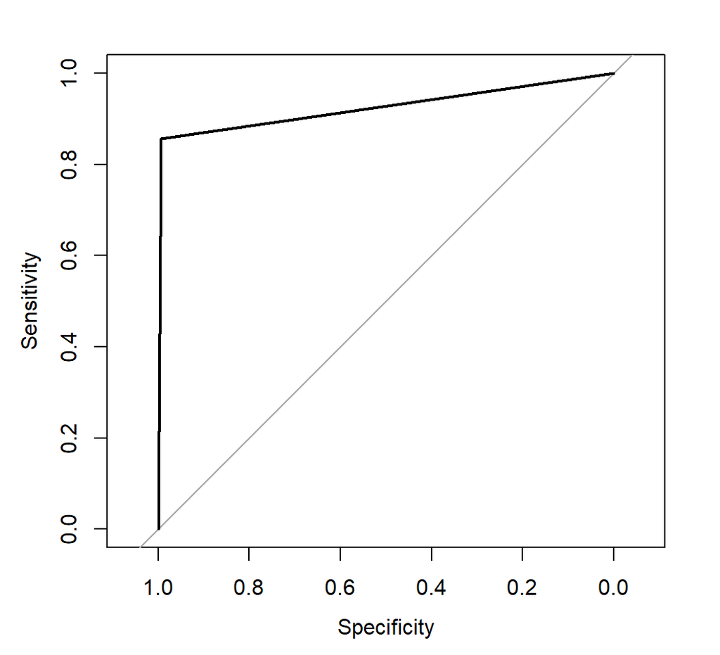

```r
#ROC/AUC
pred.knn <-predict(knn.mod, hold_out, probability = TRUE)
pred.knn <-as.ordered(pred.knn)

roc.knn <-multiclass.roc(predictor = pred.knn, response = hold_out$Class, plot=TRUE)
```

```r
auc.knn <-roc.knn$auc

#calculating values for CV table
#optimal k
tune.knn <-knn.mod$bestTune[,1]
#confusion matrix
tp.knn <- (c.matrixknn$table[1,1]) #true positive
fp.knn <- (c.matrixknn$table[1,2]) # false positive
fn.knn <- (c.matrixknn$table[2,1]) #false negative
tn.knn <- (c.matrixknn$table[2,2]) # true negative
cp.knn<- tp.knn + fn.knn #condition positive
cn.knn <- fp.knn + tn.knn #condition negative
total.knn <- tp.knn+fp.knn+fn.knn+tn.knn

precision.knn <- tp.knn/(tp.knn+fp.knn)

tpr.knn <- tp.knn/cp.knn #true positive rate/sensitivity
fpr.knn <- fp.knn/cn.knn #false positive rate
accuracy.knn <- c.matrixknn$overall["Accuracy"]
```

## Penalized Logistic Regression (ElasticNet)

```r
#deciding which penalized log reg model to use
library(glmnet)
#prep
x.mat <- model.matrix(Class~., data= pix_data)
y <- pix_data$Class
#lambda grid
grid=10^seq(10,-2,length=100)

plr.spec <- trainControl(method = "cv", number = 10)

set.seed(16454)

#ridge regression
ridge<- train(Class~., data=pix_data, method ="glmnet", tuneGrid = expand.grid(alpha=0, lambda=grid), metric = "Accuracy")
ridge.lam <- ridge$bestTune['lambda']
ridge.acc <- ridge$results[6,3]

lasso <- train(Class~., data=pix_data, method ="glmnet", tuneGrid = expand.grid(alpha=1, lambda=grid), metric = "Accuracy")
lasso.lam <- lasso$bestTune['lambda']
lasso.acc <- lasso$results[1,3]

#elasticnet(final model)
elastic.spec <-trainControl(method = "cv", number = 10, classProbs = TRUE)
set.seed(94)
elastic.mod <- train(Class~., data=pix_data, method = "glmnet", trControl = elastic.spec,  metric = "Accuracy")

elastic.lam <- elastic.mod$bestTune[,2]
elastic.acc <- elastic.mod$results[7,3]

#comparing accuracy across all three
acc.table <- data.frame(matrix(ncol = 3, nrow = 1))
colnames(acc.table) <- c("Ridge", "Lasso", "ElasticNet")
row.names(acc.table) <- ("Accuracy")
acc.table[1,1] <- ridge.acc
acc.table[1,2] <- lasso.acc
acc.table[1,3] <- elastic.acc

#show final table
print(acc.table)
```

```
#>            Ridge     Lasso ElasticNet
#> Accuracy 0.96793 0.9758088  0.9952246
```

### Modeling best fit for Penalized Regression (ElasticNet)

```r
#predict on test data
elastic.pred <-predict(elastic.mod, hold_out)
#confusion matrix
c.matrixelastic <- confusionMatrix(data=elastic.pred, reference = hold_out$Class)
c.matrixelastic
```

```
#> Confusion Matrix and Statistics
#>
#>            Reference
#> Prediction  Not.Tarp Blue.Tarp
#>   Not.Tarp   1979907       221
#>   Blue.Tarp     9790     18705
#>
#>                Accuracy : 0.995
#>                  95% CI : (0.9949, 0.9951)
#>     No Information Rate : 0.9906
#>     P-Value [Acc > NIR] : < 2.2e-16
#>
#>                   Kappa : 0.7865
#>
#>  Mcnemar's Test P-Value : < 2.2e-16
#>
#>             Sensitivity : 0.9951
#>             Specificity : 0.9883
#>          Pos Pred Value : 0.9999
#>          Neg Pred Value : 0.6564
#>              Prevalence : 0.9906
#>          Detection Rate : 0.9857
#>    Detection Prevalence : 0.9858
#>       Balanced Accuracy : 0.9917
#>
#>        'Positive' Class : Not.Tarp
#>
```

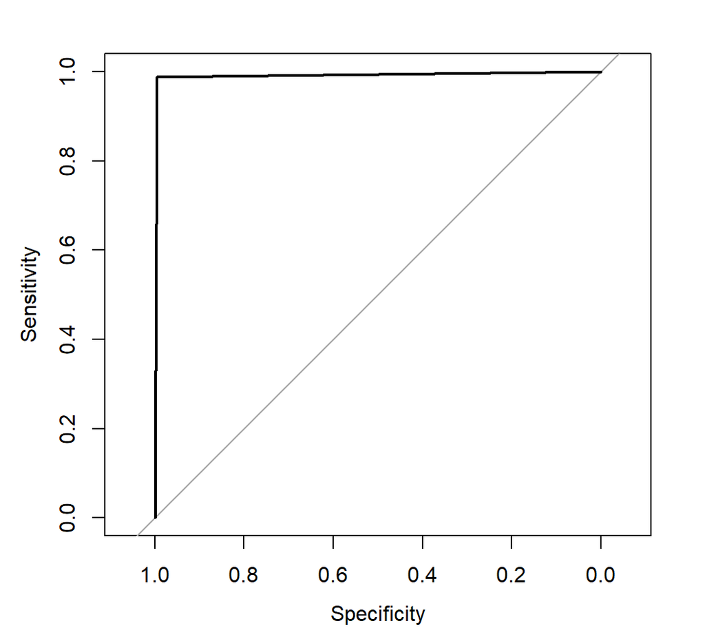

```r
#ROC/AUC
pred.elastic <-predict(elastic.mod, hold_out, probability = TRUE)
pred.elastic <-as.ordered(pred.elastic)

roc.elastic <-multiclass.roc(predictor = pred.elastic, response = hold_out$Class, plot=TRUE)
```

```r
auc.elastic <-roc.elastic$auc

#calculating values for CV table
#optimal lambda
tune.elastic <-elastic.mod$bestTune[1,2]
#confusion matrix
tp.elastic <- (c.matrixelastic$table[1,1]) #true positive
fp.elastic <- (c.matrixelastic$table[1,2]) # false positive
fn.elastic <- (c.matrixelastic$table[2,1]) #false negative
tn.elastic <- (c.matrixelastic$table[2,2]) # true negative
cp.elastic<- tp.elastic + fn.elastic #condition positive
cn.elastic <- fp.elastic + tn.elastic #condition negative
total.elastic <- tp.elastic+fp.elastic+fn.elastic+tn.elastic

precision.elastic <- tp.elastic/(tp.elastic+fp.elastic)

tpr.elastic <- tp.elastic/cp.elastic #true positive rate/sensitivity
fpr.elastic <- fp.elastic/cn.elastic #false positive rate
accuracy.elastic <- c.matrixelastic$overall["Accuracy"]
```

## Random Forest (RF)

```
#> Random Forest
#>
#> 63241 samples
#>     3 predictor
#>     2 classes: 'Blue.Tarp', 'Not.Tarp'
#>
#> No pre-processing
#> Resampling: Cross-Validated (10 fold)
#> Summary of sample sizes: 56917, 56917, 56916, 56918, 56916, 56917, ...
#> Resampling results:
#>
#>   Accuracy   Kappa
#>   0.9972328  0.954871
#>
#> Tuning parameter 'mtry' was held constant at a value of 2
```

[output not shown]

[output not shown]

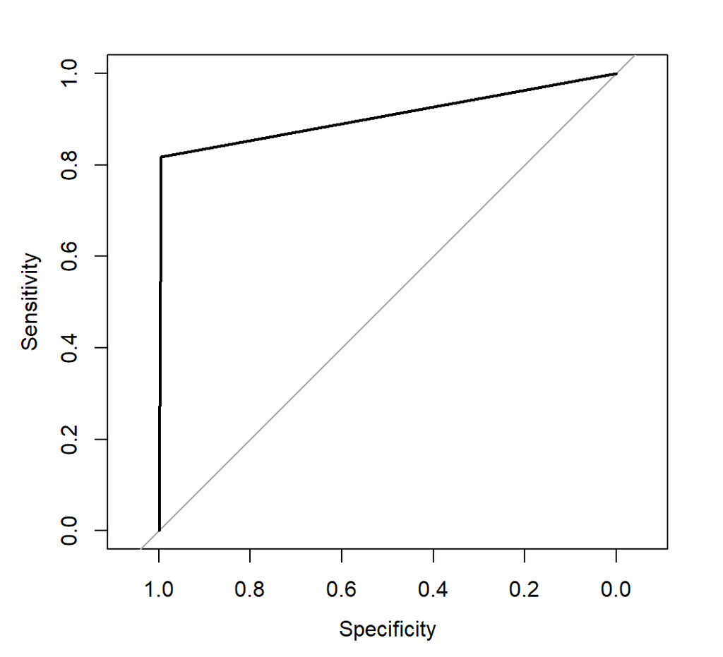

```
#> Confusion Matrix and Statistics
#>
#>            Reference
#> Prediction  Not.Tarp Blue.Tarp
#>   Not.Tarp   1979704      3446
#>   Blue.Tarp     9993     15480
#>
#>                Accuracy : 0.9933
#>                  95% CI : (0.9932, 0.9934)
#>     No Information Rate : 0.9906
#>     P-Value [Acc > NIR] : < 2.2e-16
#>
#>                   Kappa : 0.694
#>
#>  Mcnemar's Test P-Value : < 2.2e-16
#>
#>             Sensitivity : 0.9950
#>             Specificity : 0.8179
#>          Pos Pred Value : 0.9983
#>          Neg Pred Value : 0.6077
#>              Prevalence : 0.9906
#>          Detection Rate : 0.9856
#>    Detection Prevalence : 0.9873
#>       Balanced Accuracy : 0.9065
#>
#>        'Positive' Class : Not.Tarp
#>
```

## Support Vector Machines (SVM)

### Determining Which SVM method

```r
library(kernlab)
svm.spec <- trainControl(method="cv", number = 10, savePredictions = TRUE)

#linear
svm.mod.lin <- train(Class~., data = pix_data, method = "svmLinear", trControl = svm.spec)
svm.mod.lin
```

```
#> Support Vector Machines with Linear Kernel
#>
#> 63241 samples
#>     3 predictor
#>     2 classes: 'Blue.Tarp', 'Not.Tarp'
#>
#> No pre-processing
#> Resampling: Cross-Validated (10 fold)
#> Summary of sample sizes: 56917, 56918, 56916, 56917, 56917, 56916, ...
#> Resampling results:
#>
#>   Accuracy   Kappa
#>   0.9949874  0.9142268
#>
#> Tuning parameter 'C' was held constant at a value of 1
```

```r
# best parameters
lin.best <- svm.mod.lin$bestTune
lin.cost <- svm.mod.lin$bestTune[1,1]

# final linear model
#svm.mod.linf <- svm(Class~., data=pix_data, kernel="linear", cost=lin.cost, scale = FALSE)


#radial
svm.mod.rad <- train(Class~., data = pix_data, method = "svmRadial", trControl = svm.spec)
svm.mod.rad
```

```
#> Support Vector Machines with Radial Basis Function Kernel
#>
#> 63241 samples
#>     3 predictor
#>     2 classes: 'Blue.Tarp', 'Not.Tarp'
#>
#> No pre-processing
#> Resampling: Cross-Validated (10 fold)
#> Summary of sample sizes: 56917, 56917, 56917, 56917, 56917, 56916, ...
#> Resampling results across tuning parameters:
#>
#>   C     Accuracy   Kappa
#>   0.25  0.9967426  0.9469719
#>   0.50  0.9969324  0.9501103
#>   1.00  0.9970905  0.9527765
#>
#> Tuning parameter 'sigma' was held constant at a value of 8.434688
#> Accuracy was used to select the optimal model using the largest value.
#> The final values used for the model were sigma = 8.434688 and C = 1.
```

```r
# best parameters
rad.best <- svm.mod.rad$bestTune
rad.gam <- svm.mod.rad$bestTune[1,1]
rad.cost <-svm.mod.rad$bestTune[1,2]

#final radial mod
svm.mod.radf <- svm(Class~., data=pix_data, kernel="radial",  gamma=rad.gam, cost=rad.cost, scale = FALSE)


svm_table <- data.frame(matrix(ncol = 3, nrow = 1))
colnames(svm_table)<-c("Linear", "Radial", "Poly")
row.names(svm_table)<- c("Accuracy")

svm_table[1,1] <- 0.9949874 # linear accuracy
svm_table[1,2] <- 0.9970272 # radial accuracy
```

```r
#poly
library(e1071)

#need to split training set into a much smaller chunk in order to train in a timely manner
#set up split
set.seed(55)
sample <- createDataPartition(pix_data$Class, p=0.4, list = FALSE)
svmpoly <- pix_data[sample,]

#tuning parameters on 40% of training data
tune.out2=tune(svm, Class~., data=svmpoly, kernel="poly", ranges=list(cost=c(0.1,1,10,100),gamma=c(0.5,1,2,3,4.5)))
summary(tune.out2)
```

```
#>
#> Parameter tuning of 'svm':
#>
#> - sampling method: 10-fold cross validation
#>
#> - best parameters:
#>  cost gamma
#>   100     2
#>
#> - best performance: 0.003597229
#>
#> - Detailed performance results:
#>     cost gamma       error   dispersion
#> 1    0.1   0.5 0.014507429 0.0030268427
#> 2    1.0   0.5 0.008538315 0.0027892823
#> 3   10.0   0.5 0.005099346 0.0012558590
#> 4  100.0   0.5 0.004111094 0.0008577187
#> 5    0.1   1.0 0.008815058 0.0027883893
#> 6    1.0   1.0 0.005296990 0.0011662319
#> 7   10.0   1.0 0.004190145 0.0009163838
#> 8  100.0   1.0 0.003755347 0.0006248136
#> 9    0.1   2.0 0.005731819 0.0014338954
#> 10   1.0   2.0 0.004150604 0.0009543559
#> 11  10.0   2.0 0.003755347 0.0007275036
#> 12 100.0   2.0 0.003597229 0.0006573751
#> 13   0.1   3.0 0.004704042 0.0010446331
#> 14   1.0   3.0 0.003794873 0.0006767977
#> 15  10.0   3.0 0.003676280 0.0007463618
#> 16 100.0   3.0 0.010356138 0.0211022804
#> 17   0.1   4.5 0.004190145 0.0009715510
#> 18   1.0   4.5 0.003755347 0.0006248136
#> 19  10.0   4.5 0.003636754 0.0006665274
#> 20 100.0   4.5 0.085812684 0.1317946046
```

```r
#best parameters
tune.out2$best.parameters
```

```
#>    cost gamma
#> 12  100     2
```

```r
poly.gam <- tune.out2$best.parameters[1,2]
poly.cost <- tune.out2$best.parameters[1,1]

acc.poly <- 1 - tune.out2$best.performance

#final model with best parameters
#svm.mod.pol <- svm(Class~., data=pix_data, kernel="poly",  gamma=poly.gam, cost=poly.cost, scale = FALSE)
#svm.mod.pol

svm_table[1,3] <- acc.poly

#table comparing accuracy across SVM kernels
svm_table
```

```
#>             Linear    Radial      Poly
#> Accuracy 0.9949874 0.9970272 0.9964028
```

### Prediction,Confusion Matrix, and ROC/AUC Curve

```r
#predict
svm.pred <- predict(svm.mod.rad, hold_out)
#confusion matrix
c.matrixsvm <- confusionMatrix(data=svm.pred, reference = hold_out$Class)
c.matrixsvm
```

```
#> Confusion Matrix and Statistics
#>
#>            Reference
#> Prediction  Not.Tarp Blue.Tarp
#>   Not.Tarp   1975536     11161
#>   Blue.Tarp    14161      7765
#>
#>                Accuracy : 0.9874
#>                  95% CI : (0.9872, 0.9875)
#>     No Information Rate : 0.9906
#>     P-Value [Acc > NIR] : 1
#>
#>                   Kappa : 0.3738
#>
#>  Mcnemar's Test P-Value : <2e-16
#>
#>             Sensitivity : 0.9929
#>             Specificity : 0.4103
#>          Pos Pred Value : 0.9944
#>          Neg Pred Value : 0.3541
#>              Prevalence : 0.9906
#>          Detection Rate : 0.9835
#>    Detection Prevalence : 0.9891
#>       Balanced Accuracy : 0.7016
#>
#>        'Positive' Class : Not.Tarp
#>
```

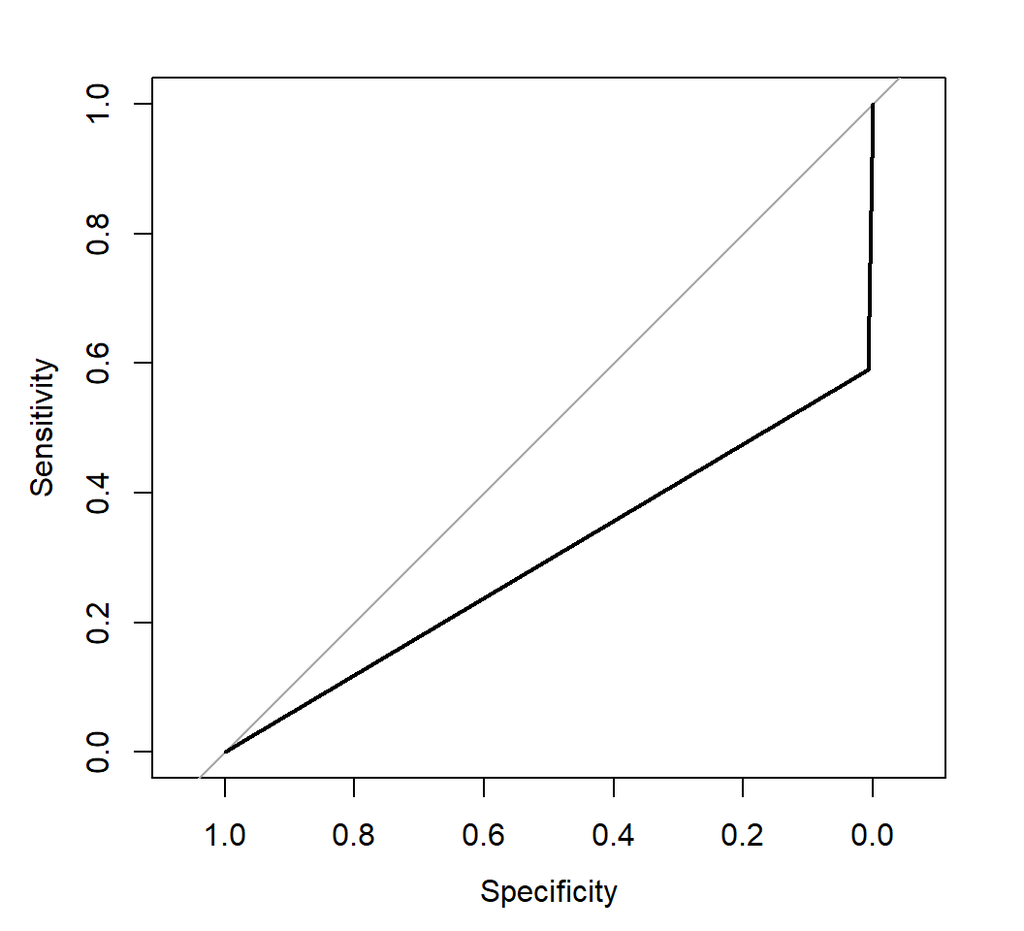

```r
#ROC/AUC
pred.svm <-predict(svm.mod.rad, hold_out, probability = TRUE)
pred.svm <-as.ordered(pred.svm)

roc.svm <-multiclass.roc(predictor = pred.svm, response = hold_out$Class, plot=TRUE)
```

```r
auc.svm <-roc.svm$auc

#calculating values for CV table
#optimal  values
rad.gam <- svm.mod.rad$bestTune[1,1]
rad.cost <-svm.mod.rad$bestTune[1,2]
#confusion matrix
tp.svm <- (c.matrixsvm$table[1,1]) #true positive
fp.svm <- (c.matrixsvm$table[1,2]) # false positive
fn.svm <- (c.matrixsvm$table[2,1]) #false negative
tn.svm <- (c.matrixsvm$table[2,2]) # true negative
cp.svm<- tp.svm + fn.svm #condition positive
cn.svm <- fp.svm + tn.svm #condition negative
total.svm <- tp.svm+fp.svm+fn.svm+tn.svm

precision.svm <- tp.svm/(tp.svm+fp.svm)

tpr.svm <- tp.svm/cp.svm #true positive rate/sensitivity
fpr.svm <- fp.svm/cn.svm #false positive rate
accuracy.svm <- c.matrixsvm$overall["Accuracy"]
```

# Results (Cross-Validation)

```r
cv_table <- data.frame(matrix(ncol = 7, nrow = 7))
colnames(cv_table)<-c("Tuning", "AUROC", "Threshold", "Accuracy", "TPR", "FPR", "Precision")
row.names(cv_table)<- c("Log Reg", "LDA", "QDA","KNN", "PLR", "RF", "SVM")

#adding in log reg values
cv_table[1,1] <- "-"
cv_table[1,2] <- auc.log
cv_table[1,3] <- threshold.log
cv_table[1,4] <- accuracy.log
cv_table[1,5] <- tpr.log
cv_table[1,6] <- fpr.log
cv_table[1,7] <- precision.log

#adding in lda values
cv_table[2,1] <- "-"
cv_table[2,2] <- auc.lda
cv_table[2,3] <- "0.5"
cv_table[2,4] <- accuracy.lda
cv_table[2,5] <- tpr.lda
cv_table[2,6] <- fpr.lda
cv_table[2,7] <- precision.lda

#adding in qda values
cv_table[3,1] <- "-"
cv_table[3,2] <- auc.qda
cv_table[3,3] <- "0.5"
cv_table[3,4] <- accuracy.qda
cv_table[3,5] <- tpr.qda
cv_table[3,6] <- fpr.qda
cv_table[3,7] <- precision.qda

#adding in KNN values
cv_table[4,1] <- tune.knn
cv_table[4,2] <- auc.knn
cv_table[4,3] <- "-"
cv_table[4,4] <- accuracy.knn
cv_table[4,5] <- tpr.knn
cv_table[4,6] <- fpr.knn
cv_table[4,7] <- precision.knn

#adding in ElasticNet values
cv_table[5,1] <- tune.elastic
cv_table[5,2] <- auc.elastic
cv_table[5,3] <- "-"
cv_table[5,4] <- accuracy.elastic
cv_table[5,5] <- tpr.elastic
cv_table[5,6] <- fpr.elastic
cv_table[5,7] <- precision.elastic

#adding in Random Forest values
cv_table[6,1] <- "2"
cv_table[6,2] <- auc.rf
cv_table[6,3] <- "-"
cv_table[6,4] <- accuracy.rf
cv_table[6,5] <- tpr.rf
cv_table[6,6] <- fpr.rf
cv_table[6,7] <- precision.rf

#adding in SVM values
cv_table[7,1] <- rad.gam
cv_table[7,2] <- auc.svm
cv_table[7,3] <- "-"
cv_table[7,4] <- accuracy.svm
cv_table[7,5] <- tpr.svm
cv_table[7,6] <- fpr.svm
cv_table[7,7] <- precision.svm

library(kableExtra)
kbl(cv_table)
```

Tuning

AUROC

Threshold

Accuracy

TPR

FPR

Precision

Log Reg

0.9904045

0.7

0.9898030

0.9897914

0.0089824

0.9999137

LDA

0.9242684

0.5

0.9819528

0.9897914

0.0089824

0.9999137

QDA

0.7740029

0.5

0.9923485

0.9965422

0.4485364

0.9957370

KNN

7

0.9251545

0.9923609

0.9936523

0.1434006

0.9986291

PLR

8.3221545178991e-05

0.9917013

0.9950160

0.9950797

0.0116771

0.9998884

RF

2

0.9064500

0.9933093

0.9949776

0.1820776

0.9982624

SVM

8.43468751628245

0.2984175

0.9873934

0.9928828

0.5897178

0.9943821

# Conclusions

### Conclusion #2

**A discussion or analysis justifying why your findings above are compatible or reconcilable.** In contrasting the models previously trained in part 1 with the the models trained this time around I believe that the results are compatible. This second time around there are a few factors that influenced the changes in model performance. Firstly, the amount of data available to train on increased since our original Haiti Pixels data set could now be used for training. The addition of the hold out data set also allowed the models to predict on over 2 million observations in contrast to the roughly 19 thousand observations in part 1. Another factor that changed was that this time around I used the same binary class data set of Blue Tarp vs Not Blue Tarp across all models and not just for logistic regression. In the same vein, previously I scaled the data solely for use in KNN and it was scaled such that there was information leakage. This time around, the training data was first scaled and the resulting mean and standard deviation were used to scale the hold out data set. All of these changes added up resulted in markedly improved accuracy across all of the trained models. One item to take note of, and will be discussed further in later conclusions, is the very unbalanced distribution between classes. This unbalance has a major effect on models such as Support Vector Machines which has the lowest **AUC** of **0.2984175** and the highest **FPR** of **0.5897178** despite having an accuracy of **0.9873934** which is comparable to the other top performing models.

### Conclusion #3

**A recommendation and rationale regarding which algorithm to use for detection of blue tarps** Based off of our dataset, I believe that there are a couple of options for which algorithm to use and which one is best depends on the goals of the person/group using the model. The best options for this specific data set are either PLR or Logistic Regression. If the entity using the data and models is interested in dispersing aid in a fast and efficient manner then the best option would be Logistic Regression since it has the lowest False Positive Rate. In later conclusions there is discussion on what types of data Logistic Regression performs best on which should be considered when selecting this model. If you are in a time crunch with limited resources youwwant to be as confident as possible in where you’re dispersing your limited resources. However, if an entity has plenty of resources and doesn’t mind taking risks on identifying displaced persons then PLR is a good option since it has the highest accuracy of all the models but its FPR is slightly higher(thousandths of a decimal) than Logistic Regression.

### Conclusion #4

**A discussion of the relevance of the metrics calculated in the tables to this application context** The objective of this project is to identify a model that best performs so that displaced Haitian’s can be provided assistance and resources post-earthquake. So the utmost importance is making sure that help is being provided in a timely and efficient manner. Therefore the metrics we are most concerned with are Accuracy, False Positive Rate, and AUROC (listed in no particular order). The AUCROC and FPR values account for how well a model classifys/misclassifys the data. Ideally, you want a model wuith a high AUCROC value and a low FPR value since you want to be accurate and misclassify as little as possible especially in our scenario involving human lives. Accuracy is also important but it should not be the sole metric used to determine the final/best model but rather a guiding point while considering other relavent metrics, esepcially when handling an unbalanced data set. Other metrics that are not as relevant for making decisions on models in our case are the True Positive Rate and Precision. The TPR is very similar to the accuracy metric in terms of value so it does not provide any *new* useful information that was not already available. Lastly, precision is not very helpful in our case since all the models have precision values that are similar and very high. Other metrics involved in our CV Table include tuning paramters and threshold values which have been previosuly discussed in earlier parts of this report.

### Conclusion #5

**Unbalanced Data** The data set we are handling consists of pixels used to identify blue tarps in Haiti. This means that when using images taken that the majority of pixels will not be part of a blue tarp simply due to the nature of the imaeges. Similaraly, if you were to take a picture of one side of the earth there will usually be many more ocean pixels than land pixels. This means that our data will always be unbalanced in this context. To try and balance the data would have too mean there are many more blue tarps which would then in som ways reduce the urgency for models to locate them. Regardless, the fact that are data is so unbalanced in both the training and test sets, has implications on model training and subsequent metrics. The unbalanced data’s influence is evident in our SVM model which has a high accuracy but a low AUCROC value. Literature (https://storm.cis.fordham.edu/~gweiss/papers/icdata-2019-imbalanced.pdf) indicates that SVM handles unbalanced data poorley. The same literature indicates that Logistic Regression does not handle unbalanced data well, however, our metrics for Logistic Regression and PLR contradicts the literature. There are no obvious contradictions that I can note that would indicate that their perfomance is incorrect. There are a few ways that unbalanced data can be corrected such as resampling data, obtaining more data, and using cross validation. In our case we already implemented cross-validation but one could attempt to use different seeds and different fold sizes. The use of resampling or obtaining more data is not particularly useful in our case. Unless observations came from an area with a high density of refugees, its unlikely that the data would balance and even then our model would not be very useful for the intended purpose of finding displaced refugees. Understanding the nature of our data allows us to appropiately pick models.